# Risk Factor Analysis

## Outcome Variable

**Outcome Variable:** stunted

## Predictor Variables

**Intervention Variable:** enstunt

**Adjustment Set:**

- arm
- sex
- W_mage
- meducyrs
- feducyrs
- vagbrth
- single
- brthmon
- W_parity
- delta_W_mage
- delta_meducyrs
- delta_feducyrs
- delta_vagbrth
- delta_single
- delta_brthmon
- delta_W_parity

## Stratifying Variables

The analysis was stratified on these variable(s):

- agecat
- studyid
- country

## Data Summary

| agecat | studyid | country | enstunt | stunted | n_cell | n |
| --- | --- | --- | --- | --- | --- | --- |
| Birth | ki0047075b-MAL-ED | BANGLADESH | 0 | 0 | 210 | 257 |
| Birth | ki0047075b-MAL-ED | BANGLADESH | 0 | 1 | 0 | 257 |
| Birth | ki0047075b-MAL-ED | BANGLADESH | 1 | 0 | 0 | 257 |
| Birth | ki0047075b-MAL-ED | BANGLADESH | 1 | 1 | 47 | 257 |
| Birth | ki0047075b-MAL-ED | BRAZIL | 0 | 0 | 170 | 191 |
| Birth | ki0047075b-MAL-ED | BRAZIL | 0 | 1 | 0 | 191 |
| Birth | ki0047075b-MAL-ED | BRAZIL | 1 | 0 | 0 | 191 |
| Birth | ki0047075b-MAL-ED | BRAZIL | 1 | 1 | 21 | 191 |
| Birth | ki0047075b-MAL-ED | INDIA | 0 | 0 | 173 | 206 |
| Birth | ki0047075b-MAL-ED | INDIA | 0 | 1 | 0 | 206 |
| Birth | ki0047075b-MAL-ED | INDIA | 1 | 0 | 0 | 206 |
| Birth | ki0047075b-MAL-ED | INDIA | 1 | 1 | 33 | 206 |
| Birth | ki0047075b-MAL-ED | NEPAL | 0 | 0 | 155 | 173 |
| Birth | ki0047075b-MAL-ED | NEPAL | 0 | 1 | 0 | 173 |
| Birth | ki0047075b-MAL-ED | NEPAL | 1 | 0 | 0 | 173 |
| Birth | ki0047075b-MAL-ED | NEPAL | 1 | 1 | 18 | 173 |
| Birth | ki0047075b-MAL-ED | PERU | 0 | 0 | 253 | 287 |
| Birth | ki0047075b-MAL-ED | PERU | 0 | 1 | 0 | 287 |
| Birth | ki0047075b-MAL-ED | PERU | 1 | 0 | 0 | 287 |
| Birth | ki0047075b-MAL-ED | PERU | 1 | 1 | 34 | 287 |
| Birth | ki0047075b-MAL-ED | SOUTH AFRICA | 0 | 0 | 234 | 262 |
| Birth | ki0047075b-MAL-ED | SOUTH AFRICA | 0 | 1 | 0 | 262 |
| Birth | ki0047075b-MAL-ED | SOUTH AFRICA | 1 | 0 | 0 | 262 |
| Birth | ki0047075b-MAL-ED | SOUTH AFRICA | 1 | 1 | 28 | 262 |
| Birth | ki0047075b-MAL-ED | TANZANIA, UNITED REPUBLIC OF | 0 | 0 | 105 | 123 |
| Birth | ki0047075b-MAL-ED | TANZANIA, UNITED REPUBLIC OF | 0 | 1 | 0 | 123 |
| Birth | ki0047075b-MAL-ED | TANZANIA, UNITED REPUBLIC OF | 1 | 0 | 0 | 123 |
| Birth | ki0047075b-MAL-ED | TANZANIA, UNITED REPUBLIC OF | 1 | 1 | 18 | 123 |
| Birth | ki1000108-CMC-V-BCS-2002 | INDIA | 0 | 0 | 74 | 90 |
| Birth | ki1000108-CMC-V-BCS-2002 | INDIA | 0 | 1 | 0 | 90 |

[output cut: 314 more lines]

The following strata were considered:

- agecat: 24 months, studyid: ki0047075b-MAL-ED, country: BANGLADESH
- agecat: 24 months, studyid: ki0047075b-MAL-ED, country: BRAZIL
- agecat: 24 months, studyid: ki0047075b-MAL-ED, country: INDIA
- agecat: 24 months, studyid: ki0047075b-MAL-ED, country: NEPAL
- agecat: 24 months, studyid: ki0047075b-MAL-ED, country: PERU
- agecat: 24 months, studyid: ki0047075b-MAL-ED, country: SOUTH AFRICA
- agecat: 24 months, studyid: ki0047075b-MAL-ED, country: TANZANIA, UNITED REPUBLIC OF
- agecat: 24 months, studyid: ki1000108-CMC-V-BCS-2002, country: INDIA
- agecat: 24 months, studyid: ki1000108-IRC, country: INDIA
- agecat: 24 months, studyid: ki1017093-NIH-Birth, country: BANGLADESH
- agecat: 24 months, studyid: ki1017093b-PROVIDE, country: BANGLADESH
- agecat: 24 months, studyid: ki1017093c-NIH-Crypto, country: BANGLADESH
- agecat: 24 months, studyid: ki1066203-TanzaniaChild2, country: TANZANIA, UNITED REPUBLIC OF
- agecat: 24 months, studyid: ki1101329-Keneba, country: GAMBIA
- agecat: 24 months, studyid: ki1113344-GMS-Nepal, country: NEPAL
- agecat: 24 months, studyid: ki1114097-CMIN, country: BANGLADESH
- agecat: 24 months, studyid: ki1114097-CMIN, country: GUINEA-BISSAU
- agecat: 24 months, studyid: ki1114097-CMIN, country: PERU
- agecat: 24 months, studyid: ki1114097-CONTENT, country: PERU
- agecat: 24 months, studyid: ki1119695-PROBIT, country: BELARUS
- agecat: 24 months, studyid: ki1126311-ZVITAMBO, country: ZIMBABWE
- agecat: 24 months, studyid: ki1135781-COHORTS, country: GUATEMALA
- agecat: 24 months, studyid: ki1135781-COHORTS, country: INDIA
- agecat: 24 months, studyid: ki1135781-COHORTS, country: PHILIPPINES
- agecat: 24 months, studyid: ki1148112-LCNI-5, country: MALAWI
- agecat: 24 months, studyid: kiGH5241-JiVitA-3, country: BANGLADESH
- agecat: 24 months, studyid: kiGH5241-JiVitA-4, country: BANGLADESH
- agecat: 6 months, studyid: ki0047075b-MAL-ED, country: BANGLADESH
- agecat: 6 months, studyid: ki0047075b-MAL-ED, country: BRAZIL
- agecat: 6 months, studyid: ki0047075b-MAL-ED, country: INDIA
- agecat: 6 months, studyid: ki0047075b-MAL-ED, country: NEPAL
- agecat: 6 months, studyid: ki0047075b-MAL-ED, country: PERU
- agecat: 6 months, studyid: ki0047075b-MAL-ED, country: SOUTH AFRICA
- agecat: 6 months, studyid: ki0047075b-MAL-ED, country: TANZANIA, UNITED REPUBLIC OF
- agecat: 6 months, studyid: ki1000108-CMC-V-BCS-2002, country: INDIA
- agecat: 6 months, studyid: ki1000108-IRC, country: INDIA
- agecat: 6 months, studyid: ki1000109-EE, country: PAKISTAN
- agecat: 6 months, studyid: ki1000109-ResPak, country: PAKISTAN
- agecat: 6 months, studyid: ki1000304b-SAS-CompFeed, country: INDIA
- agecat: 6 months, studyid: ki1000304b-SAS-FoodSuppl, country: INDIA
- agecat: 6 months, studyid: ki1017093-NIH-Birth, country: BANGLADESH
- agecat: 6 months, studyid: ki1017093b-PROVIDE, country: BANGLADESH
- agecat: 6 months, studyid: ki1017093c-NIH-Crypto, country: BANGLADESH
- agecat: 6 months, studyid: ki1066203-TanzaniaChild2, country: TANZANIA, UNITED REPUBLIC OF
- agecat: 6 months, studyid: ki1101329-Keneba, country: GAMBIA
- agecat: 6 months, studyid: ki1112895-Guatemala BSC, country: GUATEMALA
- agecat: 6 months, studyid: ki1113344-GMS-Nepal, country: NEPAL
- agecat: 6 months, studyid: ki1114097-CMIN, country: BANGLADESH
- agecat: 6 months, studyid: ki1114097-CMIN, country: BRAZIL
- agecat: 6 months, studyid: ki1114097-CMIN, country: GUINEA-BISSAU
- agecat: 6 months, studyid: ki1114097-CMIN, country: PERU
- agecat: 6 months, studyid: ki1114097-CONTENT, country: PERU
- agecat: 6 months, studyid: ki1119695-PROBIT, country: BELARUS
- agecat: 6 months, studyid: ki1126311-ZVITAMBO, country: ZIMBABWE
- agecat: 6 months, studyid: ki1135781-COHORTS, country: GUATEMALA
- agecat: 6 months, studyid: ki1135781-COHORTS, country: INDIA
- agecat: 6 months, studyid: ki1135781-COHORTS, country: PHILIPPINES
- agecat: 6 months, studyid: ki1148112-LCNI-5, country: MALAWI
- agecat: 6 months, studyid: kiGH5241-JiVitA-3, country: BANGLADESH
- agecat: 6 months, studyid: kiGH5241-JiVitA-4, country: BANGLADESH
- agecat: Birth, studyid: ki0047075b-MAL-ED, country: BANGLADESH
- agecat: Birth, studyid: ki0047075b-MAL-ED, country: BRAZIL
- agecat: Birth, studyid: ki0047075b-MAL-ED, country: INDIA
- agecat: Birth, studyid: ki0047075b-MAL-ED, country: NEPAL
- agecat: Birth, studyid: ki0047075b-MAL-ED, country: PERU
- agecat: Birth, studyid: ki0047075b-MAL-ED, country: SOUTH AFRICA
- agecat: Birth, studyid: ki0047075b-MAL-ED, country: TANZANIA, UNITED REPUBLIC OF
- agecat: Birth, studyid: ki1000108-CMC-V-BCS-2002, country: INDIA
- agecat: Birth, studyid: ki1000108-IRC, country: INDIA
- agecat: Birth, studyid: ki1000109-EE, country: PAKISTAN
- agecat: Birth, studyid: ki1000109-ResPak, country: PAKISTAN
- agecat: Birth, studyid: ki1000304b-SAS-CompFeed, country: INDIA
- agecat: Birth, studyid: ki1017093-NIH-Birth, country: BANGLADESH
- agecat: Birth, studyid: ki1017093c-NIH-Crypto, country: BANGLADESH
- agecat: Birth, studyid: ki1101329-Keneba, country: GAMBIA
- agecat: Birth, studyid: ki1114097-CMIN, country: BANGLADESH
- agecat: Birth, studyid: ki1114097-CMIN, country: BRAZIL
- agecat: Birth, studyid: ki1114097-CMIN, country: PERU
- agecat: Birth, studyid: ki1114097-CONTENT, country: PERU
- agecat: Birth, studyid: ki1119695-PROBIT, country: BELARUS
- agecat: Birth, studyid: ki1126311-ZVITAMBO, country: ZIMBABWE
- agecat: Birth, studyid: ki1135781-COHORTS, country: GUATEMALA
- agecat: Birth, studyid: ki1135781-COHORTS, country: INDIA
- agecat: Birth, studyid: ki1135781-COHORTS, country: PHILIPPINES
- agecat: Birth, studyid: kiGH5241-JiVitA-3, country: BANGLADESH
- agecat: Birth, studyid: kiGH5241-JiVitA-4, country: BANGLADESH

### Dropped Strata

Some strata were dropped due to rare outcomes:

- agecat: Birth, studyid: ki0047075b-MAL-ED, country: BANGLADESH
- agecat: Birth, studyid: ki0047075b-MAL-ED, country: BRAZIL
- agecat: Birth, studyid: ki0047075b-MAL-ED, country: INDIA
- agecat: Birth, studyid: ki0047075b-MAL-ED, country: NEPAL
- agecat: Birth, studyid: ki0047075b-MAL-ED, country: PERU
- agecat: Birth, studyid: ki0047075b-MAL-ED, country: SOUTH AFRICA
- agecat: Birth, studyid: ki0047075b-MAL-ED, country: TANZANIA, UNITED REPUBLIC OF
- agecat: Birth, studyid: ki1000108-CMC-V-BCS-2002, country: INDIA
- agecat: Birth, studyid: ki1000108-IRC, country: INDIA
- agecat: Birth, studyid: ki1000109-EE, country: PAKISTAN
- agecat: Birth, studyid: ki1000109-ResPak, country: PAKISTAN
- agecat: Birth, studyid: ki1000304b-SAS-CompFeed, country: INDIA
- agecat: Birth, studyid: ki1017093-NIH-Birth, country: BANGLADESH
- agecat: Birth, studyid: ki1017093c-NIH-Crypto, country: BANGLADESH
- agecat: Birth, studyid: ki1101329-Keneba, country: GAMBIA
- agecat: Birth, studyid: ki1114097-CMIN, country: BANGLADESH
- agecat: Birth, studyid: ki1114097-CMIN, country: BRAZIL
- agecat: Birth, studyid: ki1114097-CMIN, country: PERU
- agecat: Birth, studyid: ki1114097-CONTENT, country: PERU
- agecat: Birth, studyid: ki1119695-PROBIT, country: BELARUS
- agecat: Birth, studyid: ki1126311-ZVITAMBO, country: ZIMBABWE
- agecat: Birth, studyid: ki1135781-COHORTS, country: GUATEMALA
- agecat: Birth, studyid: ki1135781-COHORTS, country: INDIA
- agecat: Birth, studyid: ki1135781-COHORTS, country: PHILIPPINES
- agecat: Birth, studyid: kiGH5241-JiVitA-3, country: BANGLADESH
- agecat: Birth, studyid: kiGH5241-JiVitA-4, country: BANGLADESH
- agecat: 6 months, studyid: ki0047075b-MAL-ED, country: BRAZIL
- agecat: 6 months, studyid: ki0047075b-MAL-ED, country: NEPAL
- agecat: 6 months, studyid: ki1114097-CMIN, country: BRAZIL
- agecat: 6 months, studyid: ki1148112-LCNI-5, country: MALAWI
- agecat: 24 months, studyid: ki0047075b-MAL-ED, country: BRAZIL
- agecat: 24 months, studyid: ki0047075b-MAL-ED, country: TANZANIA, UNITED REPUBLIC OF
- agecat: 24 months, studyid: ki1066203-TanzaniaChild2, country: TANZANIA, UNITED REPUBLIC OF
- agecat: 24 months, studyid: ki1119695-PROBIT, country: BELARUS

## Methods Detail

We’re interested in the causal parameters $E[Y_a]$ for all values of $a \in \mathcal{A}$. These parameters represent the mean outcome if, possibly contrary to fact, we intervened to set all units to have $A=a$. Under the randomization and positivity assumptions, these are identified by the statistical parameters $\psi_a=E_W[E_{Y|A,W}(Y|A=a,W)]$. In addition, we’re interested in the mean of $Y$, $E[Y]$ under no intervention (the observed mean). We will estimate these parameters by using SuperLearner to fit the relevant likelihood factors – $E_{Y|A,W}(Y|A=a,W)$ and $p(A=a|W)$, and then updating our likelihood fit using a joint TMLE.

For unadjusted analyses ($W=\{\}$), initial likelihoods were estimated using Lrnr_glm to estimate the simple $E(Y|A)$ and Lrnr_mean to estimate $p(A)$. For adjusted analyses, a small library containing Lrnr_glmnet, Lrnr_xgboost, and Lrnr_mean was used.

Having estimated these parameters, we will then use the delta method to estimate relative risks and attributable risks relative to a prespecified baseline level of $A$.

# Results Detail

## Results Plots

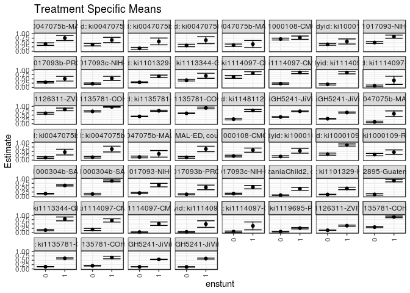

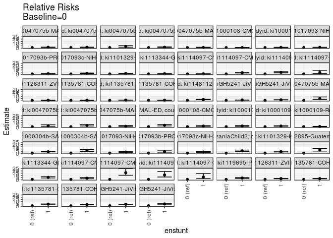

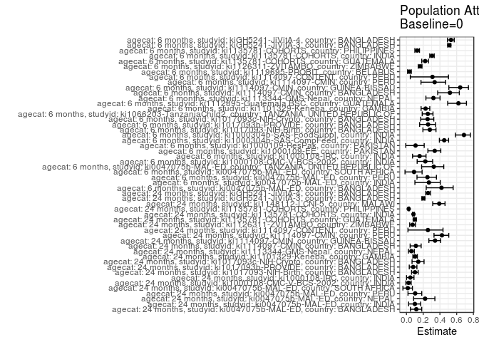

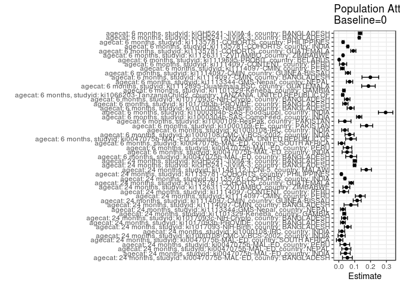

## Results Table

### Parameter: TSM

| agecat | studyid | country | intervention_level | baseline_level | estimate | ci_lower | ci_upper |
| --- | --- | --- | --- | --- | --- | --- | --- |
| 6 months | ki0047075b-MAL-ED | BANGLADESH | 0 | NA | 0.1085085 | 0.0654172 | 0.1515999 |
| 6 months | ki0047075b-MAL-ED | BANGLADESH | 1 | NA | 0.5765046 | 0.4148630 | 0.7381462 |
| 6 months | ki0047075b-MAL-ED | INDIA | 0 | NA | 0.1426625 | 0.0935035 | 0.1918215 |
| 6 months | ki0047075b-MAL-ED | INDIA | 1 | NA | 0.4589176 | 0.2957873 | 0.6220478 |
| 6 months | ki0047075b-MAL-ED | PERU | 0 | NA | 0.1646253 | 0.1175919 | 0.2116587 |
| 6 months | ki0047075b-MAL-ED | PERU | 1 | NA | 0.6330258 | 0.4662016 | 0.7998501 |
| 6 months | ki0047075b-MAL-ED | SOUTH AFRICA | 0 | NA | 0.1790393 | 0.1292860 | 0.2287927 |
| 6 months | ki0047075b-MAL-ED | SOUTH AFRICA | 1 | NA | 0.3600000 | 0.1714720 | 0.5485280 |
| 6 months | ki0047075b-MAL-ED | TANZANIA, UNITED REPUBLIC OF | 0 | NA | 0.1581734 | 0.1084500 | 0.2078967 |
| 6 months | ki0047075b-MAL-ED | TANZANIA, UNITED REPUBLIC OF | 1 | NA | 0.6403234 | 0.4834811 | 0.7971656 |
| 6 months | ki1000108-CMC-V-BCS-2002 | INDIA | 0 | NA | 0.2328832 | 0.1845489 | 0.2812176 |
| 6 months | ki1000108-CMC-V-BCS-2002 | INDIA | 1 | NA | 0.5694351 | 0.4489267 | 0.6899435 |
| 6 months | ki1000108-IRC | INDIA | 0 | NA | 0.2070799 | 0.1652180 | 0.2489419 |
| 6 months | ki1000108-IRC | INDIA | 1 | NA | 0.5365801 | 0.3972068 | 0.6759533 |
| 6 months | ki1000109-EE | PAKISTAN | 0 | NA | 0.3435970 | 0.2839683 | 0.4032257 |
| 6 months | ki1000109-EE | PAKISTAN | 1 | NA | 0.8652206 | 0.8047479 | 0.9256933 |
| 6 months | ki1000109-ResPak | PAKISTAN | 0 | NA | 0.3147908 | 0.2449783 | 0.3846034 |
| 6 months | ki1000109-ResPak | PAKISTAN | 1 | NA | 0.4542420 | 0.3251312 | 0.5833529 |
| 6 months | ki1000304b-SAS-CompFeed | INDIA | 0 | NA | 0.1560294 | 0.1364616 | 0.1755972 |
| 6 months | ki1000304b-SAS-CompFeed | INDIA | 1 | NA | 0.6275947 | 0.5932493 | 0.6619401 |
| 6 months | ki1000304b-SAS-FoodSuppl | INDIA | 0 | NA | 0.1341916 | 0.0900936 | 0.1782896 |
| 6 months | ki1000304b-SAS-FoodSuppl | INDIA | 1 | NA | 0.8902693 | 0.8397761 | 0.9407624 |
| 6 months | ki1017093-NIH-Birth | BANGLADESH | 0 | NA | 0.1933564 | 0.1569742 | 0.2297385 |
| 6 months | ki1017093-NIH-Birth | BANGLADESH | 1 | NA | 0.6464767 | 0.5462294 | 0.7467241 |
| 6 months | ki1017093b-PROVIDE | BANGLADESH | 0 | NA | 0.1195457 | 0.0917255 | 0.1473658 |
| 6 months | ki1017093b-PROVIDE | BANGLADESH | 1 | NA | 0.5138904 | 0.3809070 | 0.6468738 |
| 6 months | ki1017093c-NIH-Crypto | BANGLADESH | 0 | NA | 0.1567882 | 0.1279845 | 0.1855919 |
| 6 months | ki1017093c-NIH-Crypto | BANGLADESH | 1 | NA | 0.5316195 | 0.4317453 | 0.6314936 |
| 6 months | ki1066203-TanzaniaChild2 | TANZANIA, UNITED REPUBLIC OF | 0 | NA | 0.0722902 | 0.0606331 | 0.0839472 |
| 6 months | ki1066203-TanzaniaChild2 | TANZANIA, UNITED REPUBLIC OF | 1 | NA | 0.4345044 | 0.3508082 | 0.5182006 |

[output cut: 74 more lines]

### Parameter: E(Y)

| agecat | studyid | country | intervention_level | baseline_level | estimate | ci_lower | ci_upper |
| --- | --- | --- | --- | --- | --- | --- | --- |
| 6 months | ki0047075b-MAL-ED | BANGLADESH | NA | NA | 0.1867220 | 0.1374205 | 0.2360234 |
| 6 months | ki0047075b-MAL-ED | INDIA | NA | NA | 0.1949153 | 0.1442678 | 0.2455627 |
| 6 months | ki0047075b-MAL-ED | PERU | NA | NA | 0.2197802 | 0.1705687 | 0.2689917 |
| 6 months | ki0047075b-MAL-ED | SOUTH AFRICA | NA | NA | 0.1968504 | 0.1478551 | 0.2458457 |
| 6 months | ki0047075b-MAL-ED | TANZANIA, UNITED REPUBLIC OF | NA | NA | 0.2348178 | 0.1818480 | 0.2877876 |
| 6 months | ki1000108-CMC-V-BCS-2002 | INDIA | NA | NA | 0.3008130 | 0.2539566 | 0.3476694 |
| 6 months | ki1000108-IRC | INDIA | NA | NA | 0.2457002 | 0.2038248 | 0.2875757 |
| 6 months | ki1000109-EE | PAKISTAN | NA | NA | 0.5188172 | 0.4679751 | 0.5696593 |
| 6 months | ki1000109-ResPak | PAKISTAN | NA | NA | 0.3531915 | 0.2919518 | 0.4144312 |
| 6 months | ki1000304b-SAS-CompFeed | INDIA | NA | NA | 0.2844311 | 0.2666491 | 0.3022132 |
| 6 months | ki1000304b-SAS-FoodSuppl | INDIA | NA | NA | 0.4289474 | 0.3791199 | 0.4787748 |
| 6 months | ki1017093-NIH-Birth | BANGLADESH | NA | NA | 0.2681564 | 0.2306532 | 0.3056597 |
| 6 months | ki1017093b-PROVIDE | BANGLADESH | NA | NA | 0.1612350 | 0.1313580 | 0.1911120 |
| 6 months | ki1017093c-NIH-Crypto | BANGLADESH | NA | NA | 0.2097902 | 0.1799252 | 0.2396552 |
| 6 months | ki1066203-TanzaniaChild2 | TANZANIA, UNITED REPUBLIC OF | NA | NA | 0.0970922 | 0.0842059 | 0.1099785 |
| 6 months | ki1101329-Keneba | GAMBIA | NA | NA | 0.1412159 | 0.1262788 | 0.1561530 |
| 6 months | ki1112895-Guatemala BSC | GUATEMALA | NA | NA | 0.3010033 | 0.2489243 | 0.3530824 |
| 6 months | ki1113344-GMS-Nepal | NEPAL | NA | NA | 0.2113677 | 0.1776128 | 0.2451225 |
| 6 months | ki1114097-CMIN | BANGLADESH | NA | NA | 0.3827160 | 0.3214780 | 0.4439541 |
| 6 months | ki1114097-CMIN | GUINEA-BISSAU | NA | NA | 0.0896226 | 0.0703861 | 0.1088591 |
| 6 months | ki1114097-CMIN | PERU | NA | NA | 0.0675039 | 0.0480051 | 0.0870027 |
| 6 months | ki1114097-CONTENT | PERU | NA | NA | 0.0883721 | 0.0503437 | 0.1264005 |
| 6 months | ki1119695-PROBIT | BELARUS | NA | NA | 0.0626864 | 0.0488489 | 0.0765239 |
| 6 months | ki1126311-ZVITAMBO | ZIMBABWE | NA | NA | 0.1662447 | 0.1582324 | 0.1742571 |
| 6 months | ki1135781-COHORTS | GUATEMALA | NA | NA | 0.4099896 | 0.3788775 | 0.4411017 |
| 6 months | ki1135781-COHORTS | INDIA | NA | NA | 0.1854227 | 0.1762253 | 0.1946201 |
| 6 months | ki1135781-COHORTS | PHILIPPINES | NA | NA | 0.2112260 | 0.1958496 | 0.2266024 |
| 6 months | kiGH5241-JiVitA-3 | BANGLADESH | NA | NA | 0.2513830 | 0.2432594 | 0.2595066 |
| 6 months | kiGH5241-JiVitA-4 | BANGLADESH | NA | NA | 0.2525357 | 0.2384780 | 0.2665934 |
| 24 months | ki0047075b-MAL-ED | BANGLADESH | NA | NA | 0.4622642 | 0.3949918 | 0.5295365 |
| 24 months | ki0047075b-MAL-ED | INDIA | NA | NA | 0.4185022 | 0.3541865 | 0.4828179 |
| 24 months | ki0047075b-MAL-ED | NEPAL | NA | NA | 0.2149123 | 0.1614774 | 0.2683472 |
| 24 months | ki0047075b-MAL-ED | PERU | NA | NA | 0.3681592 | 0.3013164 | 0.4350020 |
| 24 months | ki0047075b-MAL-ED | SOUTH AFRICA | NA | NA | 0.3529412 | 0.2921001 | 0.4137823 |
| 24 months | ki1000108-CMC-V-BCS-2002 | INDIA | NA | NA | 0.7150538 | 0.6691221 | 0.7609854 |
| 24 months | ki1000108-IRC | INDIA | NA | NA | 0.4156479 | 0.3678270 | 0.4634689 |
| 24 months | ki1017093-NIH-Birth | BANGLADESH | NA | NA | 0.5547786 | 0.5076945 | 0.6018626 |
| 24 months | ki1017093b-PROVIDE | BANGLADESH | NA | NA | 0.3292894 | 0.2909105 | 0.3676684 |
| 24 months | ki1017093c-NIH-Crypto | BANGLADESH | NA | NA | 0.2568093 | 0.2190047 | 0.2946140 |
| 24 months | ki1101329-Keneba | GAMBIA | NA | NA | 0.3344928 | 0.3122213 | 0.3567642 |
| 24 months | ki1113344-GMS-Nepal | NEPAL | NA | NA | 0.4468938 | 0.4032281 | 0.4905594 |
| 24 months | ki1114097-CMIN | BANGLADESH | NA | NA | 0.6818182 | 0.6230135 | 0.7406228 |
| 24 months | ki1114097-CMIN | GUINEA-BISSAU | NA | NA | 0.3393829 | 0.2998111 | 0.3789548 |
| 24 months | ki1114097-CMIN | PERU | NA | NA | 0.3193473 | 0.2751780 | 0.3635166 |
| 24 months | ki1114097-CONTENT | PERU | NA | NA | 0.1280488 | 0.0767522 | 0.1793453 |
| 24 months | ki1126311-ZVITAMBO | ZIMBABWE | NA | NA | 0.6520788 | 0.6083612 | 0.6957964 |
| 24 months | ki1135781-COHORTS | GUATEMALA | NA | NA | 0.7912395 | 0.7669103 | 0.8155688 |
| 24 months | ki1135781-COHORTS | INDIA | NA | NA | 0.4621723 | 0.4487989 | 0.4755457 |
| 24 months | ki1135781-COHORTS | PHILIPPINES | NA | NA | 0.6167689 | 0.5974942 | 0.6360437 |
| 24 months | ki1148112-LCNI-5 | MALAWI | NA | NA | 0.4421416 | 0.4016536 | 0.4826297 |
| 24 months | kiGH5241-JiVitA-3 | BANGLADESH | NA | NA | 0.4907322 | 0.4775988 | 0.5038655 |
| 24 months | kiGH5241-JiVitA-4 | BANGLADESH | NA | NA | 0.3922559 | 0.3752678 | 0.4092440 |

### Parameter: RR

| agecat | studyid | country | intervention_level | baseline_level | estimate | ci_lower | ci_upper |
| --- | --- | --- | --- | --- | --- | --- | --- |
| 6 months | ki0047075b-MAL-ED | BANGLADESH | 0 | 0 | 1.000000 | 1.0000000 | 1.000000 |
| 6 months | ki0047075b-MAL-ED | BANGLADESH | 1 | 0 | 5.312988 | 3.2667426 | 8.640976 |
| 6 months | ki0047075b-MAL-ED | INDIA | 0 | 0 | 1.000000 | 1.0000000 | 1.000000 |
| 6 months | ki0047075b-MAL-ED | INDIA | 1 | 0 | 3.216805 | 1.9599999 | 5.279508 |
| 6 months | ki0047075b-MAL-ED | PERU | 0 | 0 | 1.000000 | 1.0000000 | 1.000000 |
| 6 months | ki0047075b-MAL-ED | PERU | 1 | 0 | 3.845252 | 2.6134694 | 5.657601 |
| 6 months | ki0047075b-MAL-ED | SOUTH AFRICA | 0 | 0 | 1.000000 | 1.0000000 | 1.000000 |
| 6 months | ki0047075b-MAL-ED | SOUTH AFRICA | 1 | 0 | 2.010732 | 1.1114293 | 3.637696 |
| 6 months | ki0047075b-MAL-ED | TANZANIA, UNITED REPUBLIC OF | 0 | 0 | 1.000000 | 1.0000000 | 1.000000 |
| 6 months | ki0047075b-MAL-ED | TANZANIA, UNITED REPUBLIC OF | 1 | 0 | 4.048238 | 2.7145276 | 6.037231 |
| 6 months | ki1000108-CMC-V-BCS-2002 | INDIA | 0 | 0 | 1.000000 | 1.0000000 | 1.000000 |
| 6 months | ki1000108-CMC-V-BCS-2002 | INDIA | 1 | 0 | 2.445153 | 1.8161067 | 3.292082 |
| 6 months | ki1000108-IRC | INDIA | 0 | 0 | 1.000000 | 1.0000000 | 1.000000 |
| 6 months | ki1000108-IRC | INDIA | 1 | 0 | 2.591174 | 1.8657315 | 3.598686 |
| 6 months | ki1000109-EE | PAKISTAN | 0 | 0 | 1.000000 | 1.0000000 | 1.000000 |
| 6 months | ki1000109-EE | PAKISTAN | 1 | 0 | 2.518126 | 2.0881008 | 3.036712 |
| 6 months | ki1000109-ResPak | PAKISTAN | 0 | 0 | 1.000000 | 1.0000000 | 1.000000 |
| 6 months | ki1000109-ResPak | PAKISTAN | 1 | 0 | 1.442996 | 1.0056540 | 2.070532 |
| 6 months | ki1000304b-SAS-CompFeed | INDIA | 0 | 0 | 1.000000 | 1.0000000 | 1.000000 |
| 6 months | ki1000304b-SAS-CompFeed | INDIA | 1 | 0 | 4.022285 | 3.5761399 | 4.524089 |
| 6 months | ki1000304b-SAS-FoodSuppl | INDIA | 0 | 0 | 1.000000 | 1.0000000 | 1.000000 |
| 6 months | ki1000304b-SAS-FoodSuppl | INDIA | 1 | 0 | 6.634314 | 4.7531743 | 9.259942 |
| 6 months | ki1017093-NIH-Birth | BANGLADESH | 0 | 0 | 1.000000 | 1.0000000 | 1.000000 |
| 6 months | ki1017093-NIH-Birth | BANGLADESH | 1 | 0 | 3.343447 | 2.6235305 | 4.260914 |
| 6 months | ki1017093b-PROVIDE | BANGLADESH | 0 | 0 | 1.000000 | 1.0000000 | 1.000000 |
| 6 months | ki1017093b-PROVIDE | BANGLADESH | 1 | 0 | 4.298695 | 3.0337683 | 6.091031 |
| 6 months | ki1017093c-NIH-Crypto | BANGLADESH | 0 | 0 | 1.000000 | 1.0000000 | 1.000000 |
| 6 months | ki1017093c-NIH-Crypto | BANGLADESH | 1 | 0 | 3.390686 | 2.6065414 | 4.410729 |
| 6 months | ki1066203-TanzaniaChild2 | TANZANIA, UNITED REPUBLIC OF | 0 | 0 | 1.000000 | 1.0000000 | 1.000000 |
| 6 months | ki1066203-TanzaniaChild2 | TANZANIA, UNITED REPUBLIC OF | 1 | 0 | 6.010559 | 4.6755388 | 7.726772 |

[output cut: 74 more lines]

### Parameter: PAR

| agecat | studyid | country | intervention_level | baseline_level | estimate | ci_lower | ci_upper |
| --- | --- | --- | --- | --- | --- | --- | --- |
| 6 months | ki0047075b-MAL-ED | BANGLADESH | 0 | NA | 0.0782134 | 0.0436462 | 0.1127807 |
| 6 months | ki0047075b-MAL-ED | INDIA | 0 | NA | 0.0522527 | 0.0209759 | 0.0835295 |
| 6 months | ki0047075b-MAL-ED | PERU | 0 | NA | 0.0551549 | 0.0281615 | 0.0821483 |
| 6 months | ki0047075b-MAL-ED | SOUTH AFRICA | 0 | NA | 0.0178111 | -0.0024971 | 0.0381193 |
| 6 months | ki0047075b-MAL-ED | TANZANIA, UNITED REPUBLIC OF | 0 | NA | 0.0766445 | 0.0429963 | 0.1102927 |
| 6 months | ki1000108-CMC-V-BCS-2002 | INDIA | 0 | NA | 0.0679298 | 0.0394559 | 0.0964037 |
| 6 months | ki1000108-IRC | INDIA | 0 | NA | 0.0386203 | 0.0183647 | 0.0588760 |
| 6 months | ki1000109-EE | PAKISTAN | 0 | NA | 0.1752202 | 0.1369973 | 0.2134431 |
| 6 months | ki1000109-ResPak | PAKISTAN | 0 | NA | 0.0384007 | -0.0003439 | 0.0771453 |
| 6 months | ki1000304b-SAS-CompFeed | INDIA | 0 | NA | 0.1284017 | 0.1118628 | 0.1449406 |
| 6 months | ki1000304b-SAS-FoodSuppl | INDIA | 0 | NA | 0.2947557 | 0.2493405 | 0.3401710 |
| 6 months | ki1017093-NIH-Birth | BANGLADESH | 0 | NA | 0.0748001 | 0.0527187 | 0.0968815 |
| 6 months | ki1017093b-PROVIDE | BANGLADESH | 0 | NA | 0.0416893 | 0.0251024 | 0.0582762 |
| 6 months | ki1017093c-NIH-Crypto | BANGLADESH | 0 | NA | 0.0530020 | 0.0356307 | 0.0703733 |
| 6 months | ki1066203-TanzaniaChild2 | TANZANIA, UNITED REPUBLIC OF | 0 | NA | 0.0248020 | 0.0178607 | 0.0317432 |
| 6 months | ki1101329-Keneba | GAMBIA | 0 | NA | 0.0322749 | 0.0243766 | 0.0401732 |
| 6 months | ki1112895-Guatemala BSC | GUATEMALA | 0 | NA | 0.1869683 | 0.1443605 | 0.2295760 |
| 6 months | ki1113344-GMS-Nepal | NEPAL | 0 | NA | 0.0680945 | 0.0482973 | 0.0878917 |
| 6 months | ki1114097-CMIN | BANGLADESH | 0 | NA | 0.1988789 | 0.1461726 | 0.2515853 |
| 6 months | ki1114097-CMIN | GUINEA-BISSAU | 0 | NA | 0.0575682 | 0.0418318 | 0.0733045 |
| 6 months | ki1114097-CMIN | PERU | 0 | NA | 0.0227279 | 0.0110611 | 0.0343948 |
| 6 months | ki1114097-CONTENT | PERU | 0 | NA | 0.0274584 | 0.0048058 | 0.0501110 |
| 6 months | ki1119695-PROBIT | BELARUS | 0 | NA | 0.0022488 | 0.0010275 | 0.0034701 |
| 6 months | ki1126311-ZVITAMBO | ZIMBABWE | 0 | NA | 0.0271260 | 0.0232519 | 0.0310002 |
| 6 months | ki1135781-COHORTS | GUATEMALA | 0 | NA | 0.0917128 | 0.0754549 | 0.1079707 |
| 6 months | ki1135781-COHORTS | INDIA | 0 | NA | 0.0566488 | 0.0511770 | 0.0621206 |
| 6 months | ki1135781-COHORTS | PHILIPPINES | 0 | NA | 0.0271290 | 0.0211101 | 0.0331480 |
| 6 months | kiGH5241-JiVitA-3 | BANGLADESH | 0 | NA | 0.1287899 | 0.1231119 | 0.1344679 |
| 6 months | kiGH5241-JiVitA-4 | BANGLADESH | 0 | NA | 0.1344532 | 0.1230614 | 0.1458450 |
| 24 months | ki0047075b-MAL-ED | BANGLADESH | 0 | NA | 0.0544429 | 0.0237941 | 0.0850918 |
| 24 months | ki0047075b-MAL-ED | INDIA | 0 | NA | 0.0421302 | 0.0122733 | 0.0719871 |
| 24 months | ki0047075b-MAL-ED | NEPAL | 0 | NA | 0.0479448 | 0.0193750 | 0.0765146 |
| 24 months | ki0047075b-MAL-ED | PERU | 0 | NA | 0.0384236 | 0.0082035 | 0.0686437 |
| 24 months | ki0047075b-MAL-ED | SOUTH AFRICA | 0 | NA | 0.0057190 | -0.0143305 | 0.0257684 |
| 24 months | ki1000108-CMC-V-BCS-2002 | INDIA | 0 | NA | 0.0180408 | -0.0043736 | 0.0404552 |
| 24 months | ki1000108-IRC | INDIA | 0 | NA | 0.0192978 | 0.0009681 | 0.0376276 |
| 24 months | ki1017093-NIH-Birth | BANGLADESH | 0 | NA | 0.0562989 | 0.0352148 | 0.0773830 |
| 24 months | ki1017093b-PROVIDE | BANGLADESH | 0 | NA | 0.0264528 | 0.0113700 | 0.0415356 |
| 24 months | ki1017093c-NIH-Crypto | BANGLADESH | 0 | NA | 0.0363196 | 0.0175610 | 0.0550782 |
| 24 months | ki1101329-Keneba | GAMBIA | 0 | NA | 0.0346961 | 0.0256757 | 0.0437165 |
| 24 months | ki1113344-GMS-Nepal | NEPAL | 0 | NA | 0.0264539 | 0.0107653 | 0.0421424 |
| 24 months | ki1114097-CMIN | BANGLADESH | 0 | NA | 0.0765642 | 0.0332818 | 0.1198465 |
| 24 months | ki1114097-CMIN | GUINEA-BISSAU | 0 | NA | 0.1159845 | 0.0910423 | 0.1409267 |
| 24 months | ki1114097-CMIN | PERU | 0 | NA | 0.1354552 | 0.1046772 | 0.1662331 |
| 24 months | ki1114097-CONTENT | PERU | 0 | NA | 0.0328107 | 0.0039066 | 0.0617148 |
| 24 months | ki1126311-ZVITAMBO | ZIMBABWE | 0 | NA | 0.0480272 | 0.0262774 | 0.0697769 |
| 24 months | ki1135781-COHORTS | GUATEMALA | 0 | NA | 0.0785554 | 0.0647916 | 0.0923192 |
| 24 months | ki1135781-COHORTS | INDIA | 0 | NA | 0.0386500 | 0.0335421 | 0.0437580 |
| 24 months | ki1135781-COHORTS | PHILIPPINES | 0 | NA | 0.0165993 | 0.0124934 | 0.0207053 |
| 24 months | ki1148112-LCNI-5 | MALAWI | 0 | NA | 0.1731965 | 0.1406144 | 0.2057786 |
| 24 months | kiGH5241-JiVitA-3 | BANGLADESH | 0 | NA | 0.0993784 | 0.0912990 | 0.1074578 |
| 24 months | kiGH5241-JiVitA-4 | BANGLADESH | 0 | NA | 0.1014163 | 0.0906211 | 0.1122115 |

### Parameter: PAF

| agecat | studyid | country | intervention_level | baseline_level | estimate | ci_lower | ci_upper |
| --- | --- | --- | --- | --- | --- | --- | --- |
| 6 months | ki0047075b-MAL-ED | BANGLADESH | 0 | NA | 0.4188765 | 0.2361050 | 0.5579176 |
| 6 months | ki0047075b-MAL-ED | INDIA | 0 | NA | 0.2680792 | 0.1009899 | 0.4041134 |
| 6 months | ki0047075b-MAL-ED | PERU | 0 | NA | 0.2509549 | 0.1259363 | 0.3580919 |
| 6 months | ki0047075b-MAL-ED | SOUTH AFRICA | 0 | NA | 0.0904803 | -0.0172293 | 0.1867851 |
| 6 months | ki0047075b-MAL-ED | TANZANIA, UNITED REPUBLIC OF | 0 | NA | 0.3263997 | 0.1812477 | 0.4458185 |
| 6 months | ki1000108-CMC-V-BCS-2002 | INDIA | 0 | NA | 0.2258206 | 0.1277588 | 0.3128578 |
| 6 months | ki1000108-IRC | INDIA | 0 | NA | 0.1571847 | 0.0729707 | 0.2337485 |
| 6 months | ki1000109-EE | PAKISTAN | 0 | NA | 0.3377302 | 0.2562293 | 0.4103003 |
| 6 months | ki1000109-ResPak | PAKISTAN | 0 | NA | 0.1087247 | -0.0081456 | 0.2120467 |
| 6 months | ki1000304b-SAS-CompFeed | INDIA | 0 | NA | 0.4514334 | 0.3935973 | 0.5037534 |
| 6 months | ki1000304b-SAS-FoodSuppl | INDIA | 0 | NA | 0.6871606 | 0.5846012 | 0.7643988 |
| 6 months | ki1017093-NIH-Birth | BANGLADESH | 0 | NA | 0.2789419 | 0.1965247 | 0.3529051 |
| 6 months | ki1017093b-PROVIDE | BANGLADESH | 0 | NA | 0.2585624 | 0.1575859 | 0.3474354 |
| 6 months | ki1017093c-NIH-Crypto | BANGLADESH | 0 | NA | 0.2526429 | 0.1705962 | 0.3265733 |
| 6 months | ki1066203-TanzaniaChild2 | TANZANIA, UNITED REPUBLIC OF | 0 | NA | 0.2554478 | 0.1882654 | 0.3170700 |
| 6 months | ki1101329-Keneba | GAMBIA | 0 | NA | 0.2285499 | 0.1747467 | 0.2788454 |
| 6 months | ki1112895-Guatemala BSC | GUATEMALA | 0 | NA | 0.6211501 | 0.4925719 | 0.7171476 |
| 6 months | ki1113344-GMS-Nepal | NEPAL | 0 | NA | 0.3221612 | 0.2323573 | 0.4014592 |
| 6 months | ki1114097-CMIN | BANGLADESH | 0 | NA | 0.5196514 | 0.3733419 | 0.6318011 |
| 6 months | ki1114097-CMIN | GUINEA-BISSAU | 0 | NA | 0.6423398 | 0.5067369 | 0.7406641 |
| 6 months | ki1114097-CMIN | PERU | 0 | NA | 0.3366908 | 0.1734500 | 0.4676920 |
| 6 months | ki1114097-CONTENT | PERU | 0 | NA | 0.3107133 | 0.0459028 | 0.5020255 |
| 6 months | ki1119695-PROBIT | BELARUS | 0 | NA | 0.0358742 | 0.0138428 | 0.0574135 |
| 6 months | ki1126311-ZVITAMBO | ZIMBABWE | 0 | NA | 0.1631693 | 0.1404734 | 0.1852659 |
| 6 months | ki1135781-COHORTS | GUATEMALA | 0 | NA | 0.2236953 | 0.1826441 | 0.2626848 |
| 6 months | ki1135781-COHORTS | INDIA | 0 | NA | 0.3055115 | 0.2782306 | 0.3317613 |
| 6 months | ki1135781-COHORTS | PHILIPPINES | 0 | NA | 0.1284359 | 0.1003287 | 0.1556651 |
| 6 months | kiGH5241-JiVitA-3 | BANGLADESH | 0 | NA | 0.5123254 | 0.4927704 | 0.5311265 |
| 6 months | kiGH5241-JiVitA-4 | BANGLADESH | 0 | NA | 0.5324126 | 0.4905097 | 0.5708692 |
| 24 months | ki0047075b-MAL-ED | BANGLADESH | 0 | NA | 0.1177745 | 0.0476933 | 0.1826983 |
| 24 months | ki0047075b-MAL-ED | INDIA | 0 | NA | 0.1006691 | 0.0257134 | 0.1698581 |
| 24 months | ki0047075b-MAL-ED | NEPAL | 0 | NA | 0.2230902 | 0.0858752 | 0.3397085 |
| 24 months | ki0047075b-MAL-ED | PERU | 0 | NA | 0.1043668 | 0.0183268 | 0.1828656 |
| 24 months | ki0047075b-MAL-ED | SOUTH AFRICA | 0 | NA | 0.0162037 | -0.0422806 | 0.0714063 |
| 24 months | ki1000108-CMC-V-BCS-2002 | INDIA | 0 | NA | 0.0252300 | -0.0068067 | 0.0562472 |
| 24 months | ki1000108-IRC | INDIA | 0 | NA | 0.0464283 | 0.0011477 | 0.0896562 |
| 24 months | ki1017093-NIH-Birth | BANGLADESH | 0 | NA | 0.1014800 | 0.0614020 | 0.1398466 |
| 24 months | ki1017093b-PROVIDE | BANGLADESH | 0 | NA | 0.0803331 | 0.0334509 | 0.1249414 |
| 24 months | ki1017093c-NIH-Crypto | BANGLADESH | 0 | NA | 0.1414263 | 0.0666727 | 0.2101926 |
| 24 months | ki1101329-Keneba | GAMBIA | 0 | NA | 0.1037275 | 0.0764298 | 0.1302185 |
| 24 months | ki1113344-GMS-Nepal | NEPAL | 0 | NA | 0.0591950 | 0.0231471 | 0.0939126 |
| 24 months | ki1114097-CMIN | BANGLADESH | 0 | NA | 0.1122941 | 0.0441087 | 0.1756157 |
| 24 months | ki1114097-CMIN | GUINEA-BISSAU | 0 | NA | 0.3417511 | 0.2678754 | 0.4081722 |
| 24 months | ki1114097-CMIN | PERU | 0 | NA | 0.4241626 | 0.3292710 | 0.5056294 |
| 24 months | ki1114097-CONTENT | PERU | 0 | NA | 0.2562358 | 0.0179802 | 0.4366864 |
| 24 months | ki1126311-ZVITAMBO | ZIMBABWE | 0 | NA | 0.0736524 | 0.0387512 | 0.1072864 |
| 24 months | ki1135781-COHORTS | GUATEMALA | 0 | NA | 0.0992814 | 0.0801671 | 0.1179985 |
| 24 months | ki1135781-COHORTS | INDIA | 0 | NA | 0.0836269 | 0.0723560 | 0.0947609 |
| 24 months | ki1135781-COHORTS | PHILIPPINES | 0 | NA | 0.0269134 | 0.0201198 | 0.0336599 |
| 24 months | ki1148112-LCNI-5 | MALAWI | 0 | NA | 0.3917218 | 0.3137855 | 0.4608065 |
| 24 months | kiGH5241-JiVitA-3 | BANGLADESH | 0 | NA | 0.2025105 | 0.1849550 | 0.2196878 |
| 24 months | kiGH5241-JiVitA-4 | BANGLADESH | 0 | NA | 0.2585462 | 0.2304139 | 0.2856501 |